# CDS Analysis

# CDS and C&I Loans analysis

Banks vary in size and loans portfolio, and there are some correlation between size and CDS position. Thus, we normalize by creating several metrics:

```
  leverage = totalLoans/totalAssets

  loansCI_to_totalAssets = loansCI_US/totalAssets

  loansCI_to_totalLoans = loansCI_US/totalLoans

  netCDS_to_loansCI = cdsNetBuy/loansCI_US
```

Banks buy/sell CDS mainly for two activities: dealer activities and hedging activities. Our key question: how much CDS does bank use for hedging?

Instead, interesting things we see:

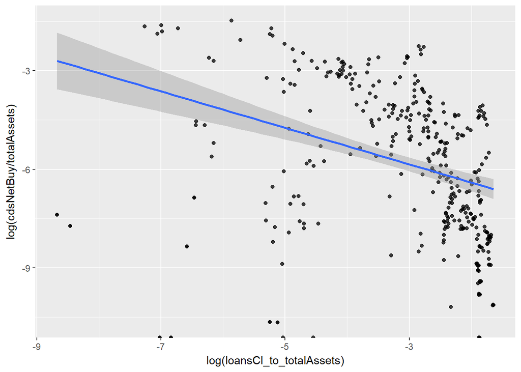

```r
ggplot(top20BankCDS,aes(x=log(loansCI_to_totalAssets), y=log(cdsNetBuy/totalAssets)))+
  geom_point(alpha = 0.75) +
  geom_smooth(method='lm',formula=y~x)
```

To formalize the analysis, we look at the statistical analysis of this:

```r
cdsLoansCI = lm(cdsNetBuy ~ loansCI_US + totalAssets , data = cdsTimeSeries, na.action = na.exclude)
summary(cdsLoansCI)
```

```
##
## Call:
## lm(formula = cdsNetBuy ~ loansCI_US + totalAssets, data = cdsTimeSeries,
##     na.action = na.exclude)
##
## Residuals:
##        Min         1Q     Median         3Q        Max
## -150093371   -1870529   -1039831    2198706  176024359
##
## Coefficients:
##               Estimate Std. Error t value Pr(>|t|)
## (Intercept)  1.313e+06  6.353e+05   2.066    0.039 *
## loansCI_US  -3.799e-01  2.412e-02 -15.753   <2e-16 ***
## totalAssets  3.714e-02  1.547e-03  24.010   <2e-16 ***
## ---
## Signif. codes:  0 '***' 0.001 '**' 0.01 '*' 0.05 '.' 0.1 ' ' 1
##
## Residual standard error: 19600000 on 1349 degrees of freedom
## Multiple R-squared:  0.3189, Adjusted R-squared:  0.3179
## F-statistic: 315.8 on 2 and 1349 DF,  p-value: < 2.2e-16
```

It seems that the inversed is true. In short, controlling for the assets size, the more C&I loan a bank has, the less CDS bought.